# Transmission Gearing Calculations

Randy Sherwood

October 10, 2015

A common source of confusion and frustration in the automotive enthusiast world revolves around the impact of changing tire sizes or even a transmission on a project car–people who aren’t particularly math-savvy don’t quite understand the impact that various changes will have on the speed their car travels. The purpose of this article is two-fold: on one hand, non-enthusiasts who aren’t mathematicians will get a glimpse into how math impacts their everyday lives; on the other, this will provide enthusiasts the tools they need to decide on an appropriate tire/wheel combination or even if a transmission change will achieve the desired effect.

## Wheels and Tires

We’ll start with the most basic changes that people would be interested in–wheel/tire combos. Almost all auto enthusiasts, and even some non-enthusiasts who just like nice wheels, have at least considered a change in the setup, but it’s common to not realize the impacts it could have. In terms of impacts on speed, the only information you need is the OEM (original equipment manufacturer) tire size, and the tire size that you’re considering changing to. Whether you change the diameter of the wheel itself, or just the dimensions of the tire, this could have an impact on the overall circumference of the tire. And if a tire has a larger circumference, a single rotation of the wheel will take you further, meaning that you’ll go faster at a given engine speed (yes, this means you could be speeding even if your speedometer shows you are not).

Tires come in sizes described by a width (in millimeters), an aspect ratio (a percentage, as an integer), and a diameter (the diameter of the wheel it’ll be mounted on, in inches–yes, we mix metric and imperial in tires). They’ll look like “195/70-14,” which translates to a tire that is 195mm wide, the sidewall is 70% of 195mm, or 136.5mm, tall, and mount on a 14 inch rim (this is the stock setup for my 1973 Datsun 240Z, if you’re wondering). We’ll use this arrangement for the example, but it’s not hard to plug in your own numbers (and I’ll provide a tool that’ll do it for you if you’re not comfortable with that).

To determine how far one rotation of the tire will take us, we need to cut through the metric/imperial nonsense and get to a circumference of the tire. Circumference, if you remember Geometry, is $2 \pi r$ or, simply, $\pi d$. We know that the wheel is 14" in diameter, and we know the sidewall of the tire is 136.5mm. There are approximately 25.4 millimeters in one inch, so the sidewall is approximately $\frac{136.5}{25.4} = 5.3740$ inches. Since the sidewall is counted twice in the overall diameter, we get a diameter of $14 + 2*5.3740 \approx 24.75$ inches. Multiplying by $\pi$, we arrive at a circumference of 77.75 inches.

Now, what if I wanted to put a different wheel and tire arrangement on my car, which included a 215/70-14 tire? Most people would look at this and think “it’s wider, but otherwise the same,” but that’s not true because now the sidewall is 70% of a wider tire. Let’s calculate the circumference of this tire:

$\pi * [14 + 2*\frac{215*.70}{25.4}] \approx 81.21$

So the new wheel/tire combo would have a circumference that is $81.21 - 77.75 \approx 3.46$ inches larger. You’re probably saying “that doesn’t sound like much,” but when that tire is rotating nearly 49,000 times in one hour (as it would when the speedometer is reading 60 on the highway), it adds up. Now here’s the important part: your car’s speedometer does not measure ground speed; it estimates ground speed based on engine rpm and gear or directly off the transmission, under the assumption that the transmission and tires are the same as what it was calibrated with. So when you put a larger tire on a car, your speedometer is now wrong. The logical followup: “how wrong is it?” Fortunately, that’s an easy question to answer. We know the car will now roll 3.46 inches further for each rotation of the tire (and, subsequently, the driveshaft). That is $\frac{3.46}{77.75} \approx 0.0445$ or 4.45% further per rotation. So your actual speed is now your speedometer’s speed + 4.45%. So if your speedometer says you’re going 60mph, you’re actually going $60*(1+0.045) \approx 63$ mph.

## Transmission and Final Drive

People doing full builds or restorations or who frequently track their cars will often consider changing the gear sets to adapt the car to different purposes: drag racers or off-roaders will want larger final drive ratios for more torque; people resto-modding classic sports cars (like myself) might want to be able to cruise on the highway at modern speeds without guzzling fuel at over 3,000 rpms, but not lose out on acceleration, which might mean a transmission with more gears. No matter the goal, it’s important to know what setup meets your needs.

One of my favorite stories on this topic was a guy who went to a 300ZX (Z32) forum looking for information on installing the six-speed from a 350Z in his 300ZX. “Why?” was the response from the knowledgeable folk. “Better fuel efficiency on the highway” was his justification. In actuality, the sixth gear of the 350Z transmission was 0.794, while the fifth gear of the 300ZX was 0.752; he would actually have **worse** fuel economy with the 350Z transmission. He assumed that, because it had one more gear, he would get better fuel mileage, but that was not true. (He would also chop off about 10mph from the 300ZX’s awesome theoretical 193mph top speed, assuming his car had the power to reach it.)

The pieces of information you need to understand how gearing relates to speed are the following:  
-Tire size (as we covered previously)  
-Transmission gear ratios  
-Final drive ratio (differential)  
-Engine RPM range (idle or the lowest rpm you’d cruise at and rev limiter)

We must briefly discuss the mechanics behind the math so that you understand why the calculation works as it does. What the gears in a transmission do is convert one rotation rate of the engine to another rotation rate at the driveshaft. If your first gear has a ratio of 3.592 (my 240Z), that means that, in first gear, the engine will rotate 3.592 times before the driveshaft completes one rotation. The final drive ratio does the same: a 3.364 final drive means that 3.364 rotations of the driveshaft will turn the wheels once. We already know how to calculate how far one rotation of the wheels will take us in inches, so I’ll point out that there are 12 inches in one foot, and 5,280 feet in one mile, and that should provide all the information we need to see how a certain engine speed (in rpm) translates to ground speed (in mph). (I’d hope it goes without saying, but there are obviously 60 minutes in one hour, since we’ll have to do a time scale conversion, as well.)

If your engine is turning at 2,000 rpm, and your first gear is 3.592, and your final drive ratio is 3.364, and you have 195/70-14 tires, you can calculate your speed as follows:

$\text{Tire Rotations} * \text{Distance Car Travels per Tire Rotation in Feet} * \text{Conversion to Miles per Hour}$ $\frac{\text{rpm}}{\text{gear ratio}*\text{final drive ratio}} * \frac{\pi * (\text{wheel diameter} + 2 * \text{aspect ratio} * \text{tire width (mm)}/25.4)}{12} * \frac{60}{5280}$ $\frac{2000}{3.592 * 3.364} * \frac{\pi * (14 + (2 * .70 * 195)/25.4)}{12} * \frac{60}{5280} \approx 12$

So a 240Z at 2,000rpm in first gear is traveling 12mph. Calculate this number for your lowest rpm and your redline rpm for each gear, and you’ll know the slowest and fastest speeds each gear can support. You can create plots to see the ranges like this, as well:

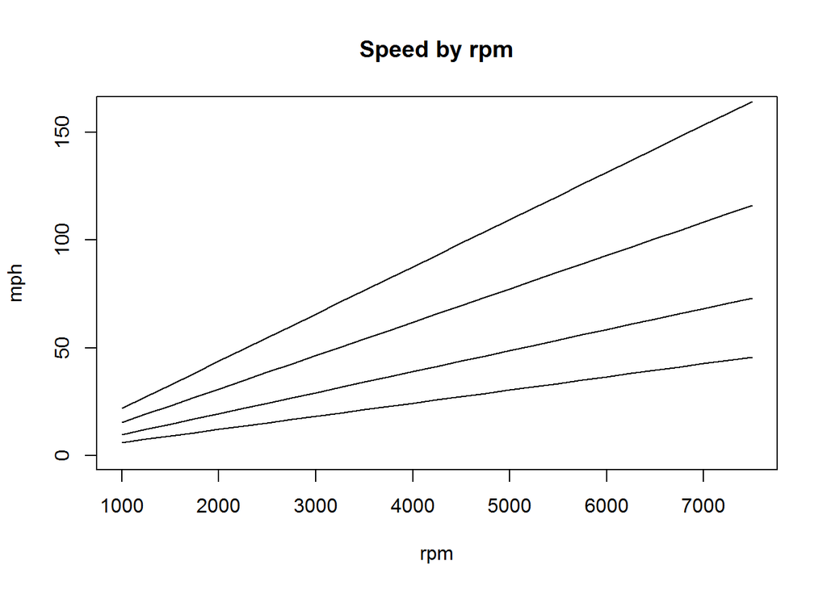

To determine what impact a different transmission or wheel/tire combo will have on your speed capabilities, calculate your current setup and the desired setup and compare the two. Consider the whole picture: if you install a different differential for the purpose of increasing acceleration, how much does that cost you in your ability to drive on the highway? If you install that six-speed, will you actually reduce fuel consumption? And so forth. There are many hurdles to overcome in building a car to fit what you want–understanding the impacts of the gearing and tires should no longer be one of them.

If you’re not comfortable performing these calculations on your own, I’ve created an [Excel spreadsheet](https://dl.dropboxusercontent.com/u/37514313/Gear_Ratio_Calculator.xlsx) to do them for you. Simply enter your numbers in the green area (or select a transmission from the dropdown, if I’ve populated that transmission’s information already) and the chart and plots will update for you. Note that the information entered in the green boxes are ignored if you select a specific transmission from the dropdown.

If you have any questions, or have an idea for an article, feel free to email me at r.sherwoodjr@gmail.com.

[Return to Index](http://rsherwoodjr.github.io/index.html)